May 2015 - master – trainr

```r
library('trainr')
path <- system.file(package = 'trainr')
```

###### GCB vs non-GCB in DLBCL (15-000)

###### A comparison of clinical outcomes by genetic subtype in patients with newly diagnosed DLBCL

###### Most recent compile: 16 June 2015

###### Department of Biostatistics and Computational Biology Dana Farber Cancer Institute

###### Statisticians: Robert Redd, email

###### All analyses were performed using R version 3.2.0 (2015-04-16) and packages `survival` v2.38.1 for time-to-event analyses; and `knitr` v1.10.5 for reproducible research.

## Summary

The primary outcome was - overall response rate (ORR)

The secondary outcomes were: - rate of PR, CR or better  
- progression-free survival  
- overall survival

## Statistical considerations

Responses to study treatment were reported as proportions with 95% exact binomial confidence intervals. Time-to-event endpoints were summarized using the Kaplan-Meier method with variance estimated using the log-log transformation.

## Administrative Information

From April 2012 to May 2013, 35 patients were enrolled on study at MGH (n = 14, 40%), BWH (n = 11, 31%), and DFCI (n = 10, 29%). As per inclusion criteria, all patients were newly diagnosed diffuse large B-cell lymphoma (DLBCL). By study design patients were stratified by subtype, and all results were performed as such.

Thirty-five (100% of) patients received at least one dose of study treatment and were included in toxicity and response analyses.

## Patient Characteristics

Patient characteristics are presented in Table 1. Seventeen (49% of) patients enrolled were male. The median age at diagnosis was 67 (range: 38 - 89). Twenty-eight (80% of) patients had International Prognostic Index (IPI) of two or more.

```r
by_var <- 'subtype'
dd1[] <- lapply(dd1, function(x) if (is.character(x)) factor(x) else x)

## wrapper functions to make tables
median_minmax <- function(...) describeMedian(..., iqr = FALSE)

get_stat <- function(var, by = by_var, data = dd1, digits = 0) {
  getDescriptionStatsBy(data[, var], by = data[, by], percentage_sign = '',
                        useNA = 'ifany', add_total_col = TRUE,
                        show_all_values = TRUE, hrzl_prop = FALSE,
                        statistics = FALSE, html = TRUE, digits = digits,
                        continuous_fn = median_minmax)
}

make_table <- function(x, ...)
  htmlTable(x, ..., ctable = TRUE, align = 'ccc', title = '',
            cgroup = c('', 'Subtype'), n.cgroup = c(1, 2),
            css.tspanner = "font-weight: 900; text-align: center;")

## table headers common to (most) tables
tbl_headers <- c(sprintf('All patients<br /><font size=1>N = %s</font>', N),
                 sprintf('%s<br><font weight=normal; size=1>n = %s</font>',
                         levels(dd1[[by_var]])[1],
                         sum(dd1[[by_var]] == levels(dd1[[by_var]])[1])),
                 sprintf('%s<br><font weight=normal; size=1>n = %s</font>',
                         levels(dd1[[by_var]])[2],
                         sum(dd1[[by_var]] == levels(dd1[[by_var]])[2])))


## select variables to use in table 1
tbl <- list()
## clin vars
tbl[['Site']] <- get_stat('site')
tbl[['Sex']] <- get_stat('sex')
tbl[['Race']] <- get_stat('race')
tbl[['Ethnicity']] <- get_stat('ethnic')
## ipi
tbl[['Age at diagnosis']] <- rbind(get_stat('age_dx'),
                                   get_stat('age_cat'))
tbl[['ECOG PS']] <- rbind(get_stat('ecog'),
                          get_stat('ecog_ipi'))
# tbl[['Disease stage']] <- rbind(get_stat('stage'),
#                                 get_stat('stage_ipi'))
tbl[['Disease stage']] <- get_stat('stage_ipi')
tbl[['LDH']] <- get_stat('ldh')
tbl[['ENS']] <- rbind(get_stat('ens'),
                      get_stat('ens_ipi'))
tbl[['IPI']] <- get_stat('ipi_risk')


## combine summaries into matrix and add total row at bottom
out <- rbind(do.call(rbind, tbl),
             c(nrow(dd), sprintf('%s (%s)', table(dd$subtype),
                                 round(table(dd$subtype) / N * 100))))
## some formatting for table
rgroup <- names(tbl)
n.rgroup <- unname(sapply(rgroup, function(x) nrow(tbl[[x]])))
n.tspanner <- sapply(list(1:4, 5:10),
                     function(x) nrow(do.call('rbind', tbl[x])))

colnames(out) <- tbl_headers
## 0 counts/percents make table harder to read
out <- gsub('0 (0)', '-', out, fixed = TRUE)


make_table(out, rgroup = c(rgroup, 'Total'), n.rgroup = c(n.rgroup, 1),
          tspanner = c('','IPI factors',''), n.tspanner = c(n.tspanner, 1),
          tfoot = paste0('<font size=1><sup>&dagger;</sup>Some note.<br />',
                         'Abbreviations: IPI, international prognostic score; ',
                         'ECOG PS, Eastern Cooperative<br />Oncology Group ',
                         'performance score.</font>'),
          caption = 'Table 1: Patient characteristics.')
```

| Table 1: Patient characteristics. | Table 1: Patient characteristics. All patients N = 35 | Table 1: Patient characteristics. | Table 1: Patient characteristics. Subtype ABC n = 15 | Table 1: Patient characteristics. Subtype GCB n = 20 |
| --- | --- | --- | --- | --- |
| Site |  |  |  |  |
| BWH | 11 (31) |  | 4 (27) | 7 (35) |
| DFCI | 10 (29) |  | 3 (20) | 7 (35) |
| MGH | 14 (40) |  | 8 (53) | 6 (30) |
| Sex |  |  |  |  |
| Female | 18 (51) |  | 5 (33) | 13 (65) |
| Male | 17 (49) |  | 10 (67) | 7 (35) |
| Race |  |  |  |  |
| Asian | 2 (6) |  | 1 (7) | 1 (5) |
| Black | 11 (31) |  | 3 (20) | 8 (40) |
| White | 22 (63) |  | 11 (73) | 11 (55) |
| Ethnicity |  |  |  |  |
| Hispanic | 5 (14) |  | 2 (13) | 3 (15) |
| Non-Hispanic | 30 (86) |  | 13 (87) | 17 (85) |
| IPI factors |  |  |  |  |
| Age at diagnosis |  |  |  |  |
| Median (range) | 67 (38 - 89) |  | 61 (39 - 89) | 68 (38 - 86) |
| 38 - 50 | 9 (26) |  | 5 (33) | 4 (20) |
| 51 - 60 | 5 (14) |  | 2 (13) | 3 (15) |
| 61 - 70 | 7 (20) |  | 3 (20) | 4 (20) |
| 71 - 80 | 9 (26) |  | 2 (13) | 7 (35) |
| 81 - 89 | 5 (14) |  | 3 (20) | 2 (10) |
| ECOG PS |  |  |  |  |
| Median (range) | 2 (0 - 4) |  | 2 (0 - 4) | 2 (0 - 4) |
| > 1 | 23 (66) |  | 10 (67) | 13 (65) |
| ≤ 1 | 12 (34) |  | 5 (33) | 7 (35) |
| Disease stage |  |  |  |  |
| Stage I/II | 21 (60) |  | 10 (67) | 11 (55) |
| Stage III/IV | 14 (40) |  | 5 (33) | 9 (45) |
| LDH |  |  |  |  |
| Elevated | 16 (46) |  | 8 (53) | 8 (40) |
| Normal | 19 (54) |  | 7 (47) | 12 (60) |
| ENS |  |  |  |  |
| Median (range) | 2 (0 - 3) |  | 2 (0 - 3) | 2 (0 - 3) |
| > 1 | 19 (54) |  | 9 (60) | 10 (50) |
| ≤ 1 | 16 (46) |  | 6 (40) | 10 (50) |
| IPI |  |  |  |  |
| Low | 7 (20) |  | 3 (20) | 4 (20) |
| Low-Int | 13 (37) |  | 5 (33) | 8 (40) |
| High-Int | 12 (34) |  | 5 (33) | 7 (35) |
| High | 3 (9) |  | 2 (13) | 1 (5) |
| Total |  |  |  |  |
|  | 35 |  | 15 (43) | 20 (57) |

## Baseline labs

Lab results at study entry are presented in Table 2. The median sum of largest tumor diameters at baseline was 70.2 for all patients and 74.7 and 69.1 for ABC and GCB suptype patients, respectively.

```r
blabs1 <- merge(blabs, dd[, c('id','subtype')])
blabs1$id <- NULL
nums <- sapply(blabs1, is.numeric)
nums <- names(nums[nums])

## calculate statistics only for the numeric lab variables
out <- setNames(lapply(names(blabs1[, nums]), function(x)
  get_stat(x, data = blabs1, digits = 1)), nums)
out <- do.call('rbind', out)
colnames(out) <- tbl_headers

## formatting
nums <- ifelse(nchar(nums) < 4, toupper(nums),
               gsub('(.)(.*)', '\\U\\1\\L\\2', nums, perl = TRUE))


make_table(out, rgroup = nums, n.rgroup = rep(1, length(nums)),
           caption = 'Table 2: Baseline lab results')
```

| Table 2: Baseline lab results | Table 2: Baseline lab results All patients N = 35 | Table 2: Baseline lab results | Table 2: Baseline lab results Subtype ABC n = 15 | Table 2: Baseline lab results Subtype GCB n = 20 |
| --- | --- | --- | --- | --- |
| LTD |  |  |  |  |
| Median (range) | 70.2 (50.4 - 98.8) |  | 74.7 (53.2 - 98.8) | 69.1 (50.4 - 97.6) |
| WBC |  |  |  |  |
| Median (range) | 11.7 (5.3 - 19.4) |  | 15.0 (5.3 - 19.0) | 10.2 (6.7 - 19.4) |
| HGB |  |  |  |  |
| Median (range) | 12.0 (5.2 - 19.5) |  | 15.3 (6.4 - 18.5) | 11.4 (5.2 - 19.5) |
| Platelets |  |  |  |  |
| Median (range) | 154.0 (116.0 - 180.0) |  | 159.0 (129.0 - 176.0) | 152.5 (116.0 - 180.0) |
| Neutrophils |  |  |  |  |
| Median (range) | 51.0 (31.0 - 66.0) |  | 50.0 (32.0 - 66.0) | 52.0 (31.0 - 65.0) |
| Lymphocytes |  |  |  |  |
| Median (range) | 29.0 (19.0 - 40.0) |  | 28.0 (20.0 - 39.0) | 29.5 (19.0 - 40.0) |
| Monocytes |  |  |  |  |
| Median (range) | 10.0 (5.0 - 17.0) |  | 9.0 (6.0 - 12.0) | 10.5 (5.0 - 17.0) |

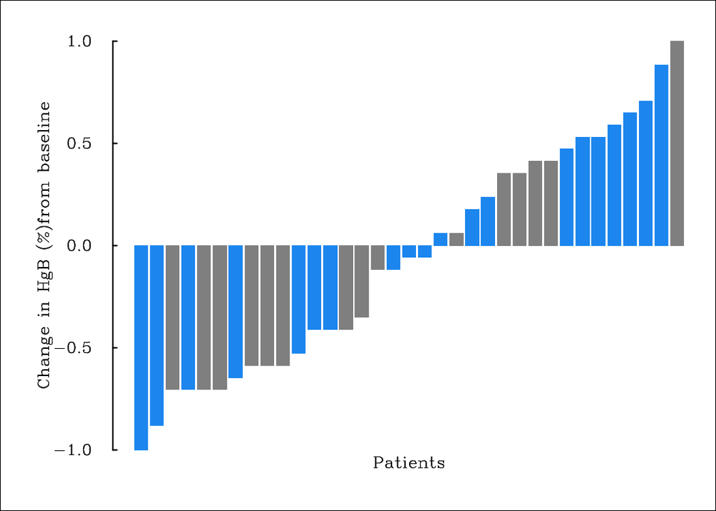

Figure I: Percent change in hemoglobin values from baseline to end of treatment. ABC and GCB patients shown in grey and blue, respectively.

```r
hgb_change <- within(merge(blabs, demo[, c('id','subtype')]), {
  change <- (hgb - elabs$hgb) / hgb
})
hgb_change <- hgb_change[order(hgb_change$change), ]


## waterfall plot
par(mar = c(3, 5.5, 2, .5), family = 'HersheySerif',
    las = 1, tcl = .2)
with(hgb_change,
     barplot(change, border = NA, xlab = 'Patients',
             ylab = 'Change in HgB (%)\nfrom baseline',
             col = ifelse(subtype %in% 'ABC', 'grey50', 'dodgerblue2')))
mtext('Patients', side = 1)
box('outer')
```

## Treatment toxicities

```r
## get tox code info
tox <- cbind(tox, rawr::match_ctc(tox$tox_code)$matches[, c('tox_desc','tox_cat')])


# ## get worst grades by id, toxicity code
# tox1 <- tox[with(tox, order(id, tox_desc, -xtfrm(tox_grade))), ]
# tox1 <- tox1[with(tox1, !duplicated(cbind(id, tox_desc))), ]
#
# tox2 <- tox_worst(tox, 'id')$tox_worst
# identical(tox1, tox2)


worst <- tox_worst(tox)$tox_worst
worst <- merge(worst, dd[, c('id','subtype')])
worst <- within(worst, {
  tox_desc <- factor(tox_desc)
  subtype <- factor(subtype)
  tox_grade12 <- ifelse(tox_grade %in% 1:2, 0, tox_grade)
  tox_grade12 <- factor(tox_grade12, levels = c(0, levels(tox_grade)),
                        labels = c('1 - 2', levels(tox_grade)))
  ## comment out to separate levels 1,2
  ## repeat similar to combine/separate levels 3,4 or others
  tox_grade <- droplevels(tox_grade12)
  worst_overall <- ave(as.numeric(tox_grade), id, FUN = max)
})


n <- table(dd$subtype)
## worst tox grade overall per pt
nn <- table(with(worst, tapply(as.numeric(tox_grade), id, max)))


tt <- list(tabler_by(worst, 'tox_desc', 'subtype', n,
                     zeros = '-')[, 1, drop = FALSE],
           tabler_by(worst[worst$subtype %in% 'ABC', ],
                     'tox_desc', 'tox_grade', n = n[1], zeros = '-'),
           tabler_by(worst[worst$subtype %in% 'GCB', ],
                     'tox_desc', 'tox_grade', n = n[2], zeros = '-'))
colnames(tt[[1]]) <- sprintf('Total<br /><font size=1>n = %s</font>', sum(n))
out <- do.call('cbind', tt)
out <- out[order(as.numeric(out[, 1]), decreasing = TRUE), ]

## no percent signs
out <- gsub('%', '', out)
```

```r
htmlTable(out, cgroup = c('', tbl_headers[-1]), n.cgroup = sapply(tt, ncol),
  tfoot = paste0('<font size=1><sup>&dagger;</sup>Percentages represent ',
            'proportion of patients out of respective phase total.</font>'),
  caption = 'Table 3: Toxicities<sup>&dagger;</sup> by subtype, grade.')
```

| Table 3: Toxicities† by subtype, grade. | Table 3: Toxicities† by subtype, grade. Total n = 35 | Table 3: Toxicities† by subtype, grade. | Table 3: Toxicities† by subtype, grade. ABC n = 15 Total | Table 3: Toxicities† by subtype, grade. ABC n = 15 1 - 2 | Table 3: Toxicities† by subtype, grade. ABC n = 15 3 | Table 3: Toxicities† by subtype, grade. ABC n = 15 4 | Table 3: Toxicities† by subtype, grade. | Table 3: Toxicities† by subtype, grade. GCB n = 20 Total | Table 3: Toxicities† by subtype, grade. GCB n = 20 1 - 2 | Table 3: Toxicities† by subtype, grade. GCB n = 20 3 | Table 3: Toxicities† by subtype, grade. GCB n = 20 4 |
| --- | --- | --- | --- | --- | --- | --- | --- | --- | --- | --- | --- |
| Anemia | 21 |  | 10 | 6 (40) | 3 (20) | 1 (7) |  | 11 | 5 (25) | 6 (30) | - |
| Hemolysis | 21 |  | 9 | 2 (13) | 6 (40) | 1 (7) |  | 12 | 6 (30) | 4 (20) | 2 (10) |
| Aortic valve disease | 19 |  | 9 | 6 (40) | 2 (13) | 1 (7) |  | 10 | 6 (30) | 4 (20) | - |
| Atrial fibrillation | 19 |  | 9 | 7 (47) | 2 (13) | - |  | 10 | 7 (35) | 1 (5) | 2 (10) |
| Disseminated intravascular coagulation | 19 |  | 10 | 3 (20) | 7 (47) | - |  | 9 | 6 (30) | 3 (15) | - |
| Atrial flutter | 18 |  | 9 | 6 (40) | 3 (20) | - |  | 9 | 4 (20) | 4 (20) | 1 (5) |
| Febrile neutropenia | 18 |  | 9 | 7 (47) | 2 (13) | - |  | 9 | 7 (35) | 2 (10) | - |
| Acute coronary syndrome | 16 |  | 6 | 5 (33) | 1 (7) | - |  | 10 | 10 (50) | - | - |
| Bone marrow hypocellular | 16 |  | 6 | 4 (27) | 2 (13) | - |  | 10 | 6 (30) | 4 (20) | - |
| Hemolytic uremic syndrome | 16 |  | 8 | 4 (27) | 3 (20) | 1 (7) |  | 8 | 7 (35) | 1 (5) | - |
| Leukocytosis | 16 |  | 5 | 4 (27) | 1 (7) | - |  | 11 | 6 (30) | 4 (20) | 1 (5) |
| Lymph node pain | 16 |  | 9 | 5 (33) | 4 (27) | - |  | 7 | 4 (20) | 3 (15) | - |
| Thrombotic thrombocytopenic purpura | 16 |  | 8 | 5 (33) | 3 (20) | - |  | 8 | 6 (30) | 2 (10) | - |
| Asystole | 14 |  | 6 | 4 (27) | 2 (13) | - |  | 8 | 7 (35) | 1 (5) | - |
| Spleen disorder | 13 |  | 6 | 4 (27) | 2 (13) | - |  | 7 | 3 (15) | 3 (15) | 1 (5) |

†Percentages represent proportion of patients out of respective phase total.

## Outcome summary

```r
## response
responders <- grepl('R', resp$resp)
pr_better <- resp$resp %in% c('PR','CR')
crs <- resp$resp %in% 'CR'


## survival models and plots
os_fit <- survfit(Surv(os_time, os_ind) ~ subtype,
                  data = dd, conf.type = 'log-log')
pfs_fit <- survfit(Surv(pfs_time, pfs_ind) ~ subtype,
                   data = dd, conf.type = 'log-log')
```

### Response to treatment

The primary outcome was overall response rate (MR, PR, CR) at end of treatment. All patients received at least one dose of study treatment and were included in response assessment, and all patients were evaluated for EOT response.

The overall response rate of MR or better was 57% (95% CI: 39 - 74%). Nine (26% of) patients experienced a PR or better at EOT (95% CI: 12 - 43%). Four (11% of) patients experienced a CR or better (95% CI: 3 - 27%).

### Time-to-event

Patients were followed for progression-free and overall survival, and results are reporte in Tables 4 and 5.

```r
pfs <- surv_table(pfs_fit, digits = 2)
os <- surv_table(os_fit, digits = 2)

f <- function(x, cap)
  htmlTable(do.call('rbind', x), caption = cap,
          tspanner = c('ABC','GCB'), n.tspanner = sapply(x, nrow))

f(pfs, cap = 'Table 4: Progression-free survival.')
```

| Table 4: Progression-free survival. Time | Table 4: Progression-free survival. No. at risk | Table 4: Progression-free survival. No. event | Table 4: Progression-free survival. Std.Error | Table 4: Progression-free survival. OR (95% CI) |
| --- | --- | --- | --- | --- |
| ABC |  |  |  |  |
| 0 | 15 | 0 | 0 | 1 (1, 1) |
| 5 | 11 | 4 | 0.11 | 0.73 (0.44, 0.89) |
| 10 | 8 | 3 | 0.13 | 0.53 (0.26, 0.74) |
| 15 | 6 | 2 | 0.13 | 0.4 (0.16, 0.63) |
| GCB |  |  |  |  |
| 0 | 20 | 0 | 0 | 1 (1, 1) |
| 5 | 19 | 1 | 0.05 | 0.95 (0.69, 0.99) |
| 10 | 10 | 9 | 0.11 | 0.5 (0.27, 0.69) |
| 15 | 9 | 1 | 0.11 | 0.45 (0.23, 0.65) |

```r
f(os, cap = 'Table 5: Overall survival.')
```

| Table 5: Overall survival. Time | Table 5: Overall survival. No. at risk | Table 5: Overall survival. No. event | Table 5: Overall survival. Std.Error | Table 5: Overall survival. OR (95% CI) |
| --- | --- | --- | --- | --- |
| ABC |  |  |  |  |
| 5 | 15 | 0 | 0 | 1 (1, 1) |
| 10 | 11 | 4 | 0.11 | 0.73 (0.44, 0.89) |
| 15 | 8 | 3 | 0.13 | 0.53 (0.26, 0.74) |
| 20 | 5 | 3 | 0.12 | 0.33 (0.12, 0.56) |
| GCB |  |  |  |  |
| 5 | 20 | 0 | 0 | 1 (1, 1) |
| 10 | 14 | 7 | 0.11 | 0.65 (0.4, 0.82) |
| 15 | 10 | 3 | 0.11 | 0.5 (0.27, 0.69) |
| 20 | 8 | 2 | 0.11 | 0.4 (0.19, 0.6) |

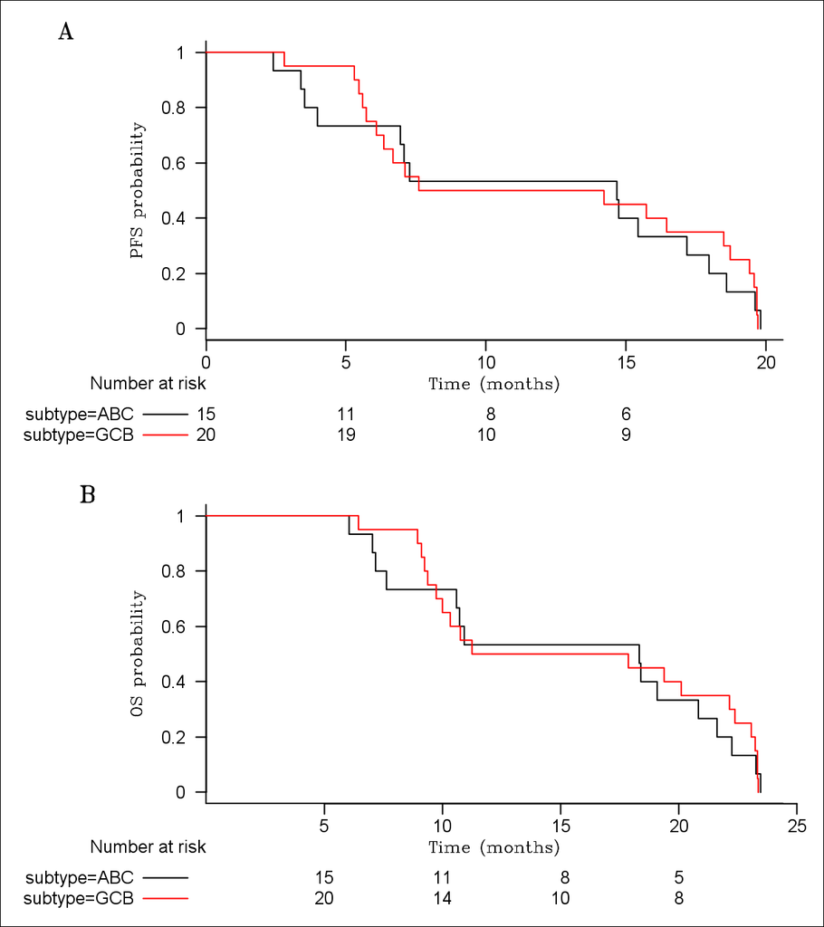

Figure II: Time-to-event endpoints, profression-free (panel A) and overall (B) survival.

```r
## survival plot wrapper
surv_plot <- function(x, ...) {
  rawr::kmplot(x, col.band = NA, col.surv = seq_along(x$strata),
               legend = FALSE, xlab = 'Time (months)',
               family = 'HersheySerif', ..., mar = c(6, 10, 2, 2))
}

mt <- function(x)
  mtext(side = 3, text = x, at = -5,
      family = 'HersheySerif', font = 2, cex = 1.5)


par(mfrow = c(2, 1), bty = 'l')
surv_plot(pfs_fit, ylab = 'PFS probability', add = TRUE)
mt('A')
surv_plot(os_fit, ylab = 'OS probability', add = TRUE)
mt('B')
box('outer')
```

## Discussion

Good programming practices and using `knitr` to create dynamic documents can make your life so much easier.

## References

Loprinzi CL. Laurie JA. Wieand HS. Krook JE. Novotny PJ. Kugler JW. Bartel J. Law M. Bateman M. Klatt NE. et al. “Prospective evaluation of prognostic variables from patient-completed questionnaires.” North Central Cancer Treatment Group. *Journal of Clinical Oncology*. 12(3):601-7, 1994.

```r
## r citation
print(citation(), style = 'html')
```

R Core Team (2015). *R: A Language and Environment for Statistical Computing*. R Foundation for Statistical Computing, Vienna, Austria. http://www.R-project.org/.

```r
print(citation(package = 'survival'), style = 'html')
```

Therneau T (2015). *A Package for Survival Analysis in S*. version 2.38, http://CRAN.R-project.org/package=survival.

Terry M. Therneau and Patricia M. Grambsch (2000). *Modeling Survival Data: Extending the Cox Model*. Springer, New York. ISBN 0-387-98784-3.

## Appendix

This is the appendix. We put long table listings and older or less relevant analyses here.

### All response data

```r
out <- as.matrix(resp)

## only show a subset
out <- rbind(out[1:10, ], '...')

htmlTable(out, caption = 'Table A1: All response data.')
```

| Table A1: All response data. id | Table A1: All response data. resp | Table A1: All response data. d_resp | Table A1: All response data. m_resp | Table A1: All response data. y_resp |
| --- | --- | --- | --- | --- |
| 1 | CR | 26 | 8 | 2013 |
| 2 | MR | 16 | 9 | 2013 |
| 3 | MR | 10 | 7 | 2013 |
| 4 | CR | 8 | 9 | 2013 |
| 5 | PD | 21 | 10 | 2013 |
| 6 | SD | 16 | 7 | 2013 |
| 7 | SD | 16 | 8 | 2013 |
| 8 | MR | 18 | 7 | 2013 |
| 9 | PD | 27 | 9 | 2013 |
| 10 | PR | 22 | 8 | 2013 |
| … | … | … | … | … |

### All toxicity data

```r
out <- as.matrix(tox)

## only show a subset
out <- rbind(out[1:10, ], '...')


htmlTable(out, align = 'cccll', caption = 'Table A2: All toxicity data.')
```

| Table A2: All toxicity data. id | Table A2: All toxicity data. tox_code | Table A2: All toxicity data. tox_grade | Table A2: All toxicity data. tox_desc | Table A2: All toxicity data. tox_cat |
| --- | --- | --- | --- | --- |
| 1 | BL102 | 1 | Bone marrow hypocellular | Blood and lymphatic system disorders |
| 1 | BL104 | 3 | Febrile neutropenia | Blood and lymphatic system disorders |
| 1 | BL105 | 3 | Hemolysis | Blood and lymphatic system disorders |
| 1 | BL105 | 2 | Hemolysis | Blood and lymphatic system disorders |
| 1 | BL105 | 1 | Hemolysis | Blood and lymphatic system disorders |
| 1 | BL108 | 2 | Lymph node pain | Blood and lymphatic system disorders |
| 1 | CA104 | 2 | Atrial fibrillation | Cardiac disorders |
| 2 | BL101 | 3 | Anemia | Blood and lymphatic system disorders |
| 2 | BL102 | 1 | Bone marrow hypocellular | Blood and lymphatic system disorders |
| 2 | BL102 | 1 | Bone marrow hypocellular | Blood and lymphatic system disorders |
| … | … | … | … | … |